# Risk Factor Analysis

## Outcome Variable

**Outcome Variable:** ever_stunted

## Predictor Variables

**Intervention Variable:** hfoodsec

**Adjustment Set:**

unadjusted

## Stratifying Variables

The analysis was stratified on these variable(s):

- agecat
- studyid

The following strata were considered:

- agecat: 12 months, studyid: ki0047075b-MAL-ED
- agecat: 12 months, studyid: ki1017093-NIH-Birth
- agecat: 12 months, studyid: ki1017093c-NIH-Crypto
- agecat: 12 months, studyid: ki1113344-GMS-Nepal
- agecat: 18 months, studyid: ki0047075b-MAL-ED
- agecat: 18 months, studyid: ki1017093-NIH-Birth
- agecat: 18 months, studyid: ki1017093c-NIH-Crypto
- agecat: 18 months, studyid: ki1113344-GMS-Nepal
- agecat: 24 months, studyid: ki0047075b-MAL-ED
- agecat: 24 months, studyid: ki1017093-NIH-Birth
- agecat: 24 months, studyid: ki1017093c-NIH-Crypto
- agecat: 24 months, studyid: ki1113344-GMS-Nepal
- agecat: 3 months, studyid: ki0047075b-MAL-ED
- agecat: 3 months, studyid: ki1017093-NIH-Birth
- agecat: 3 months, studyid: ki1017093c-NIH-Crypto
- agecat: 3 months, studyid: ki1113344-GMS-Nepal
- agecat: 6 months, studyid: ki0047075b-MAL-ED
- agecat: 6 months, studyid: ki1017093-NIH-Birth
- agecat: 6 months, studyid: ki1017093c-NIH-Crypto
- agecat: 6 months, studyid: ki1113344-GMS-Nepal

### Dropped Strata

Some strata were dropped due to rare outcomes:

- agecat: 3 months, studyid: ki1017093-NIH-Birth
- agecat: 6 months, studyid: ki1017093-NIH-Birth
- agecat: 12 months, studyid: ki1017093-NIH-Birth
- agecat: 18 months, studyid: ki1017093-NIH-Birth
- agecat: 24 months, studyid: ki1017093-NIH-Birth

## Methods Detail

We’re interested in the causal parameters $E[Y_a]$ for all values of $a \in \mathcal{A}$. These parameters represent the mean outcome if, possibly contrary to fact, we intervened to set all units to have $A=a$. Under the randomization and positivity assumptions, these are identified by the statistical parameters $\psi_a=E_W[E_{Y|A,W}(Y|A=a,W)]$. In addition, we’re interested in the mean of $Y$, $E[Y]$ under no intervention (the observed mean). We will estimate these parameters by using SuperLearner to fit the relevant likelihood factors – $E_{Y|A,W}(Y|A=a,W)$ and $p(A=a|W)$, and then updating our likelihood fit using a joint TMLE.

For unadjusted analyses ($W=\{\}$), initial likelihoods were estimated using Lrnr_glm to estimate the simple $E(Y|A)$ and Lrnr_mean to estimate $p(A)$. For adjusted analyses, a small library containing Lrnr_glmnet, Lrnr_xgboost, and Lrnr_mean was used.

Having estimated these parameters, we will then use the delta method to estimate relative risks and attributable risks relative to a prespecified baseline level of $A$.

# Results Detail

## Results Plots

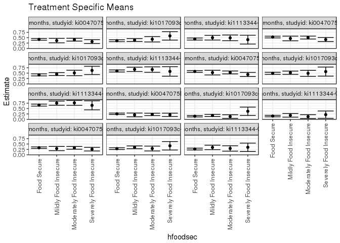

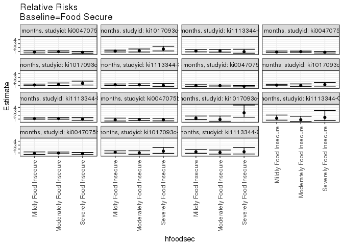

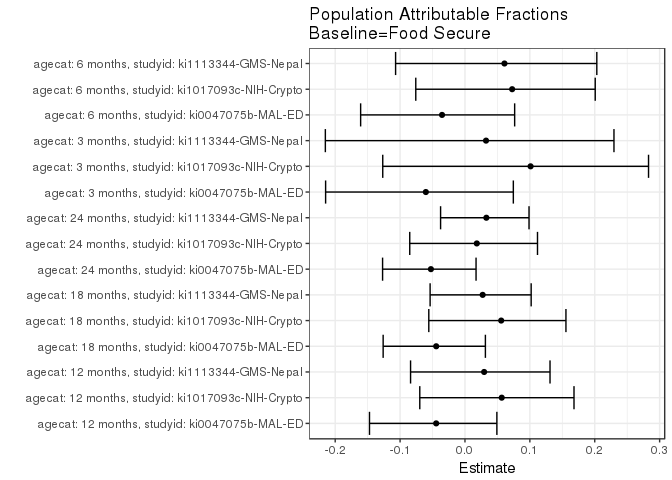

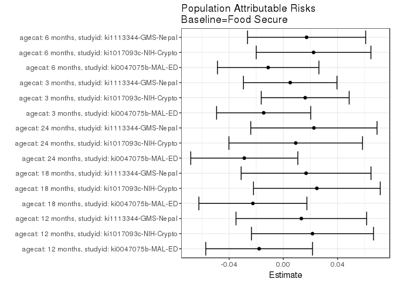

## Data Summary

| agecat | studyid | A | n | nA | nAY0 | nAY1 |
| --- | --- | --- | --- | --- | --- | --- |
| 3 months | ki0047075b-MAL-ED | Food Secure | 1009 | 607 | 452 | 155 |
| 3 months | ki0047075b-MAL-ED | Mildly Food Insecure | 1009 | 83 | 66 | 17 |
| 3 months | ki0047075b-MAL-ED | Moderately Food Insecure | 1009 | 214 | 165 | 49 |
| 3 months | ki0047075b-MAL-ED | Severely Food Insecure | 1009 | 105 | 83 | 22 |
| 3 months | ki1017093-NIH-Birth | Food Secure | 629 | 95 | 78 | 17 |
| 3 months | ki1017093-NIH-Birth | Mildly Food Insecure | 629 | 492 | 382 | 110 |
| 3 months | ki1017093-NIH-Birth | Moderately Food Insecure | 629 | 36 | 25 | 11 |
| 3 months | ki1017093-NIH-Birth | Severely Food Insecure | 629 | 6 | 4 | 2 |
| 3 months | ki1017093c-NIH-Crypto | Food Secure | 758 | 453 | 388 | 65 |
| 3 months | ki1017093c-NIH-Crypto | Mildly Food Insecure | 758 | 219 | 180 | 39 |
| 3 months | ki1017093c-NIH-Crypto | Moderately Food Insecure | 758 | 62 | 54 | 8 |
| 3 months | ki1017093c-NIH-Crypto | Severely Food Insecure | 758 | 24 | 15 | 9 |
| 3 months | ki1113344-GMS-Nepal | Food Secure | 575 | 416 | 353 | 63 |
| 3 months | ki1113344-GMS-Nepal | Mildly Food Insecure | 575 | 81 | 66 | 15 |
| 3 months | ki1113344-GMS-Nepal | Moderately Food Insecure | 575 | 55 | 48 | 7 |
| 3 months | ki1113344-GMS-Nepal | Severely Food Insecure | 575 | 23 | 18 | 5 |
| 6 months | ki0047075b-MAL-ED | Food Secure | 1006 | 605 | 407 | 198 |
| 6 months | ki0047075b-MAL-ED | Mildly Food Insecure | 1006 | 83 | 59 | 24 |
| 6 months | ki0047075b-MAL-ED | Moderately Food Insecure | 1006 | 214 | 145 | 69 |
| 6 months | ki0047075b-MAL-ED | Severely Food Insecure | 1006 | 104 | 77 | 27 |
| 6 months | ki1017093-NIH-Birth | Food Secure | 551 | 83 | 56 | 27 |
| 6 months | ki1017093-NIH-Birth | Mildly Food Insecure | 551 | 427 | 271 | 156 |
| 6 months | ki1017093-NIH-Birth | Moderately Food Insecure | 551 | 36 | 20 | 16 |
| 6 months | ki1017093-NIH-Birth | Severely Food Insecure | 551 | 5 | 3 | 2 |
| 6 months | ki1017093c-NIH-Crypto | Food Secure | 736 | 439 | 314 | 125 |
| 6 months | ki1017093c-NIH-Crypto | Mildly Food Insecure | 736 | 211 | 138 | 73 |
| 6 months | ki1017093c-NIH-Crypto | Moderately Food Insecure | 736 | 62 | 44 | 18 |
| 6 months | ki1017093c-NIH-Crypto | Severely Food Insecure | 736 | 24 | 14 | 10 |
| 6 months | ki1113344-GMS-Nepal | Food Secure | 549 | 396 | 291 | 105 |
| 6 months | ki1113344-GMS-Nepal | Mildly Food Insecure | 549 | 79 | 52 | 27 |
| 6 months | ki1113344-GMS-Nepal | Moderately Food Insecure | 549 | 51 | 36 | 15 |
| 6 months | ki1113344-GMS-Nepal | Severely Food Insecure | 549 | 23 | 15 | 8 |
| 12 months | ki0047075b-MAL-ED | Food Secure | 1005 | 605 | 351 | 254 |
| 12 months | ki0047075b-MAL-ED | Mildly Food Insecure | 1005 | 82 | 52 | 30 |
| 12 months | ki0047075b-MAL-ED | Moderately Food Insecure | 1005 | 214 | 127 | 87 |
| 12 months | ki0047075b-MAL-ED | Severely Food Insecure | 1005 | 104 | 71 | 33 |
| 12 months | ki1017093-NIH-Birth | Food Secure | 541 | 80 | 48 | 32 |
| 12 months | ki1017093-NIH-Birth | Mildly Food Insecure | 541 | 421 | 202 | 219 |
| 12 months | ki1017093-NIH-Birth | Moderately Food Insecure | 541 | 36 | 14 | 22 |
| 12 months | ki1017093-NIH-Birth | Severely Food Insecure | 541 | 4 | 1 | 3 |
| 12 months | ki1017093c-NIH-Crypto | Food Secure | 729 | 438 | 281 | 157 |
| 12 months | ki1017093c-NIH-Crypto | Mildly Food Insecure | 729 | 206 | 126 | 80 |
| 12 months | ki1017093c-NIH-Crypto | Moderately Food Insecure | 729 | 61 | 35 | 26 |
| 12 months | ki1017093c-NIH-Crypto | Severely Food Insecure | 729 | 24 | 10 | 14 |
| 12 months | ki1113344-GMS-Nepal | Food Secure | 565 | 408 | 230 | 178 |
| 12 months | ki1113344-GMS-Nepal | Mildly Food Insecure | 565 | 80 | 40 | 40 |
| 12 months | ki1113344-GMS-Nepal | Moderately Food Insecure | 565 | 55 | 28 | 27 |
| 12 months | ki1113344-GMS-Nepal | Severely Food Insecure | 565 | 22 | 13 | 9 |
| 18 months | ki0047075b-MAL-ED | Food Secure | 1005 | 605 | 285 | 320 |
| 18 months | ki0047075b-MAL-ED | Mildly Food Insecure | 1005 | 82 | 44 | 38 |
| 18 months | ki0047075b-MAL-ED | Moderately Food Insecure | 1005 | 214 | 106 | 108 |
| 18 months | ki0047075b-MAL-ED | Severely Food Insecure | 1005 | 104 | 61 | 43 |
| 18 months | ki1017093-NIH-Birth | Food Secure | 497 | 76 | 37 | 39 |
| 18 months | ki1017093-NIH-Birth | Mildly Food Insecure | 497 | 382 | 128 | 254 |
| 18 months | ki1017093-NIH-Birth | Moderately Food Insecure | 497 | 35 | 8 | 27 |
| 18 months | ki1017093-NIH-Birth | Severely Food Insecure | 497 | 4 | 1 | 3 |
| 18 months | ki1017093c-NIH-Crypto | Food Secure | 715 | 430 | 250 | 180 |
| 18 months | ki1017093c-NIH-Crypto | Mildly Food Insecure | 715 | 202 | 110 | 92 |
| 18 months | ki1017093c-NIH-Crypto | Moderately Food Insecure | 715 | 59 | 29 | 30 |
| 18 months | ki1017093c-NIH-Crypto | Severely Food Insecure | 715 | 24 | 9 | 15 |
| 18 months | ki1113344-GMS-Nepal | Food Secure | 557 | 404 | 162 | 242 |
| 18 months | ki1113344-GMS-Nepal | Mildly Food Insecure | 557 | 80 | 26 | 54 |
| 18 months | ki1113344-GMS-Nepal | Moderately Food Insecure | 557 | 54 | 18 | 36 |
| 18 months | ki1113344-GMS-Nepal | Severely Food Insecure | 557 | 19 | 8 | 11 |
| 24 months | ki0047075b-MAL-ED | Food Secure | 1000 | 604 | 255 | 349 |
| 24 months | ki0047075b-MAL-ED | Mildly Food Insecure | 1000 | 80 | 38 | 42 |
| 24 months | ki0047075b-MAL-ED | Moderately Food Insecure | 1000 | 213 | 100 | 113 |
| 24 months | ki0047075b-MAL-ED | Severely Food Insecure | 1000 | 103 | 58 | 45 |
| 24 months | ki1017093-NIH-Birth | Food Secure | 470 | 72 | 30 | 42 |
| 24 months | ki1017093-NIH-Birth | Mildly Food Insecure | 470 | 360 | 80 | 280 |
| 24 months | ki1017093-NIH-Birth | Moderately Food Insecure | 470 | 34 | 4 | 30 |
| 24 months | ki1017093-NIH-Birth | Severely Food Insecure | 470 | 4 | 1 | 3 |
| 24 months | ki1017093c-NIH-Crypto | Food Secure | 634 | 396 | 201 | 195 |
| 24 months | ki1017093c-NIH-Crypto | Mildly Food Insecure | 634 | 168 | 81 | 87 |
| 24 months | ki1017093c-NIH-Crypto | Moderately Food Insecure | 634 | 49 | 25 | 24 |
| 24 months | ki1017093c-NIH-Crypto | Severely Food Insecure | 634 | 21 | 9 | 12 |
| 24 months | ki1113344-GMS-Nepal | Food Secure | 551 | 399 | 135 | 264 |
| 24 months | ki1113344-GMS-Nepal | Mildly Food Insecure | 551 | 77 | 19 | 58 |
| 24 months | ki1113344-GMS-Nepal | Moderately Food Insecure | 551 | 55 | 13 | 42 |
| 24 months | ki1113344-GMS-Nepal | Severely Food Insecure | 551 | 20 | 7 | 13 |

## Results Table

### Parameter: TSM

| agecat | studyid | intervention_level | baseline_level | estimate | ci_lower | ci_upper |
| --- | --- | --- | --- | --- | --- | --- |
| 3 months | ki0047075b-MAL-ED | Food Secure | NA | 0.2553542 | 0.2206473 | 0.2900611 |
| 3 months | ki0047075b-MAL-ED | Mildly Food Insecure | NA | 0.2048193 | 0.1179547 | 0.2916839 |
| 3 months | ki0047075b-MAL-ED | Moderately Food Insecure | NA | 0.2289720 | 0.1726494 | 0.2852946 |
| 3 months | ki0047075b-MAL-ED | Severely Food Insecure | NA | 0.2095238 | 0.1316431 | 0.2874045 |
| 3 months | ki1017093c-NIH-Crypto | Food Secure | NA | 0.1434879 | 0.1111836 | 0.1757921 |
| 3 months | ki1017093c-NIH-Crypto | Mildly Food Insecure | NA | 0.1780822 | 0.1273788 | 0.2287856 |
| 3 months | ki1017093c-NIH-Crypto | Moderately Food Insecure | NA | 0.1290323 | 0.0455318 | 0.2125328 |
| 3 months | ki1017093c-NIH-Crypto | Severely Food Insecure | NA | 0.3750000 | 0.1811862 | 0.5688138 |
| 3 months | ki1113344-GMS-Nepal | Food Secure | NA | 0.1514423 | 0.1169642 | 0.1859204 |
| 3 months | ki1113344-GMS-Nepal | Mildly Food Insecure | NA | 0.1851852 | 0.1005178 | 0.2698526 |
| 3 months | ki1113344-GMS-Nepal | Moderately Food Insecure | NA | 0.1272727 | 0.0391168 | 0.2154287 |
| 3 months | ki1113344-GMS-Nepal | Severely Food Insecure | NA | 0.2173913 | 0.0486756 | 0.3861070 |
| 6 months | ki0047075b-MAL-ED | Food Secure | NA | 0.3272727 | 0.2898650 | 0.3646804 |
| 6 months | ki0047075b-MAL-ED | Mildly Food Insecure | NA | 0.2891566 | 0.1915726 | 0.3867406 |
| 6 months | ki0047075b-MAL-ED | Moderately Food Insecure | NA | 0.3224299 | 0.2597755 | 0.3850844 |
| 6 months | ki0047075b-MAL-ED | Severely Food Insecure | NA | 0.2596154 | 0.1753127 | 0.3439180 |
| 6 months | ki1017093c-NIH-Crypto | Food Secure | NA | 0.2847380 | 0.2424939 | 0.3269822 |
| 6 months | ki1017093c-NIH-Crypto | Mildly Food Insecure | NA | 0.3459716 | 0.2817441 | 0.4101990 |
| 6 months | ki1017093c-NIH-Crypto | Moderately Food Insecure | NA | 0.2903226 | 0.1772601 | 0.4033850 |
| 6 months | ki1017093c-NIH-Crypto | Severely Food Insecure | NA | 0.4166667 | 0.2192924 | 0.6140409 |
| 6 months | ki1113344-GMS-Nepal | Food Secure | NA | 0.2651515 | 0.2216362 | 0.3086669 |
| 6 months | ki1113344-GMS-Nepal | Mildly Food Insecure | NA | 0.3417722 | 0.2370866 | 0.4464577 |
| 6 months | ki1113344-GMS-Nepal | Moderately Food Insecure | NA | 0.2941176 | 0.1689519 | 0.4192834 |
| 6 months | ki1113344-GMS-Nepal | Severely Food Insecure | NA | 0.3478261 | 0.1530019 | 0.5426503 |
| 12 months | ki0047075b-MAL-ED | Food Secure | NA | 0.4198347 | 0.3804886 | 0.4591808 |
| 12 months | ki0047075b-MAL-ED | Mildly Food Insecure | NA | 0.3658537 | 0.2615485 | 0.4701588 |
| 12 months | ki0047075b-MAL-ED | Moderately Food Insecure | NA | 0.4065421 | 0.3406997 | 0.4723844 |
| 12 months | ki0047075b-MAL-ED | Severely Food Insecure | NA | 0.3173077 | 0.2278124 | 0.4068030 |
| 12 months | ki1017093c-NIH-Crypto | Food Secure | NA | 0.3584475 | 0.3135070 | 0.4033880 |
| 12 months | ki1017093c-NIH-Crypto | Mildly Food Insecure | NA | 0.3883495 | 0.3217493 | 0.4549497 |
| 12 months | ki1017093c-NIH-Crypto | Moderately Food Insecure | NA | 0.4262295 | 0.3020437 | 0.5504154 |
| 12 months | ki1017093c-NIH-Crypto | Severely Food Insecure | NA | 0.5833333 | 0.3859578 | 0.7807089 |
| 12 months | ki1113344-GMS-Nepal | Food Secure | NA | 0.4362745 | 0.3881112 | 0.4844378 |
| 12 months | ki1113344-GMS-Nepal | Mildly Food Insecure | NA | 0.5000000 | 0.3903376 | 0.6096624 |
| 12 months | ki1113344-GMS-Nepal | Moderately Food Insecure | NA | 0.4909091 | 0.3586731 | 0.6231451 |
| 12 months | ki1113344-GMS-Nepal | Severely Food Insecure | NA | 0.4090909 | 0.2034585 | 0.6147234 |
| 18 months | ki0047075b-MAL-ED | Food Secure | NA | 0.5289256 | 0.4891306 | 0.5687206 |
| 18 months | ki0047075b-MAL-ED | Mildly Food Insecure | NA | 0.4634146 | 0.3554301 | 0.5713992 |
| 18 months | ki0047075b-MAL-ED | Moderately Food Insecure | NA | 0.5046729 | 0.4376523 | 0.5716935 |
| 18 months | ki0047075b-MAL-ED | Severely Food Insecure | NA | 0.4134615 | 0.3187695 | 0.5081536 |
| 18 months | ki1017093c-NIH-Crypto | Food Secure | NA | 0.4186047 | 0.3719435 | 0.4652658 |
| 18 months | ki1017093c-NIH-Crypto | Mildly Food Insecure | NA | 0.4554455 | 0.3867205 | 0.5241706 |
| 18 months | ki1017093c-NIH-Crypto | Moderately Food Insecure | NA | 0.5084746 | 0.3808208 | 0.6361283 |
| 18 months | ki1017093c-NIH-Crypto | Severely Food Insecure | NA | 0.6250000 | 0.4311785 | 0.8188215 |
| 18 months | ki1113344-GMS-Nepal | Food Secure | NA | 0.5990099 | 0.5511765 | 0.6468433 |
| 18 months | ki1113344-GMS-Nepal | Mildly Food Insecure | NA | 0.6750000 | 0.5722725 | 0.7777275 |
| 18 months | ki1113344-GMS-Nepal | Moderately Food Insecure | NA | 0.6666667 | 0.5408219 | 0.7925114 |
| 18 months | ki1113344-GMS-Nepal | Severely Food Insecure | NA | 0.5789474 | 0.3567447 | 0.8011500 |
| 24 months | ki0047075b-MAL-ED | Food Secure | NA | 0.5778146 | 0.5384058 | 0.6172233 |
| 24 months | ki0047075b-MAL-ED | Mildly Food Insecure | NA | 0.5250000 | 0.4155170 | 0.6344830 |
| 24 months | ki0047075b-MAL-ED | Moderately Food Insecure | NA | 0.5305164 | 0.4634608 | 0.5975720 |
| 24 months | ki0047075b-MAL-ED | Severely Food Insecure | NA | 0.4368932 | 0.3410570 | 0.5327294 |
| 24 months | ki1017093c-NIH-Crypto | Food Secure | NA | 0.4924242 | 0.4431451 | 0.5417034 |
| 24 months | ki1017093c-NIH-Crypto | Mildly Food Insecure | NA | 0.5178571 | 0.4422385 | 0.5934758 |
| 24 months | ki1017093c-NIH-Crypto | Moderately Food Insecure | NA | 0.4897959 | 0.3497171 | 0.6298747 |
| 24 months | ki1017093c-NIH-Crypto | Severely Food Insecure | NA | 0.5714286 | 0.3596052 | 0.7832519 |
| 24 months | ki1113344-GMS-Nepal | Food Secure | NA | 0.6616541 | 0.6151863 | 0.7081219 |
| 24 months | ki1113344-GMS-Nepal | Mildly Food Insecure | NA | 0.7532468 | 0.6568645 | 0.8496290 |
| 24 months | ki1113344-GMS-Nepal | Moderately Food Insecure | NA | 0.7636364 | 0.6512549 | 0.8760179 |
| 24 months | ki1113344-GMS-Nepal | Severely Food Insecure | NA | 0.6500000 | 0.4407727 | 0.8592273 |

### Parameter: E(Y)

| agecat | studyid | intervention_level | baseline_level | estimate | ci_lower | ci_upper |
| --- | --- | --- | --- | --- | --- | --- |
| 3 months | ki0047075b-MAL-ED | NA | NA | 0.2408325 | 0.2396525 | 0.2420125 |
| 3 months | ki1017093c-NIH-Crypto | NA | NA | 0.1596306 | 0.1566089 | 0.1626523 |
| 3 months | ki1113344-GMS-Nepal | NA | NA | 0.1565217 | 0.1549600 | 0.1580835 |
| 6 months | ki0047075b-MAL-ED | NA | NA | 0.3161034 | 0.3147583 | 0.3174484 |
| 6 months | ki1017093c-NIH-Crypto | NA | NA | 0.3070652 | 0.3046172 | 0.3095132 |
| 6 months | ki1113344-GMS-Nepal | NA | NA | 0.2823315 | 0.2798004 | 0.2848626 |
| 12 months | ki0047075b-MAL-ED | NA | NA | 0.4019900 | 0.3999907 | 0.4039894 |
| 12 months | ki1017093c-NIH-Crypto | NA | NA | 0.3799726 | 0.3768577 | 0.3830875 |
| 12 months | ki1113344-GMS-Nepal | NA | NA | 0.4495575 | 0.4473463 | 0.4517688 |
| 18 months | ki0047075b-MAL-ED | NA | NA | 0.5064677 | 0.5041944 | 0.5087410 |
| 18 months | ki1017093c-NIH-Crypto | NA | NA | 0.4433566 | 0.4401872 | 0.4465261 |
| 18 months | ki1113344-GMS-Nepal | NA | NA | 0.6157989 | 0.6131638 | 0.6184340 |
| 24 months | ki0047075b-MAL-ED | NA | NA | 0.5490000 | 0.5462865 | 0.5517135 |
| 24 months | ki1017093c-NIH-Crypto | NA | NA | 0.5015773 | 0.5002395 | 0.5029151 |
| 24 months | ki1113344-GMS-Nepal | NA | NA | 0.6842105 | 0.6807580 | 0.6876631 |

### Parameter: RR

| agecat | studyid | intervention_level | baseline_level | estimate | ci_lower | ci_upper |
| --- | --- | --- | --- | --- | --- | --- |
| 3 months | ki0047075b-MAL-ED | Mildly Food Insecure | Food Secure | 0.8020987 | 0.5138242 | 1.2521060 |
| 3 months | ki0047075b-MAL-ED | Moderately Food Insecure | Food Secure | 0.8966838 | 0.6769992 | 1.1876555 |
| 3 months | ki0047075b-MAL-ED | Severely Food Insecure | Food Secure | 0.8205223 | 0.5523421 | 1.2189128 |
| 3 months | ki1017093c-NIH-Crypto | Mildly Food Insecure | Food Secure | 1.2410959 | 0.8633107 | 1.7842001 |
| 3 months | ki1017093c-NIH-Crypto | Moderately Food Insecure | Food Secure | 0.8992556 | 0.4532275 | 1.7842265 |
| 3 months | ki1017093c-NIH-Crypto | Severely Food Insecure | Food Secure | 2.6134615 | 1.4872552 | 4.5924744 |
| 3 months | ki1113344-GMS-Nepal | Mildly Food Insecure | Food Secure | 1.2228101 | 0.7337407 | 2.0378652 |
| 3 months | ki1113344-GMS-Nepal | Moderately Food Insecure | Food Secure | 0.8404040 | 0.4053590 | 1.7423542 |
| 3 months | ki1113344-GMS-Nepal | Severely Food Insecure | Food Secure | 1.4354727 | 0.6393510 | 3.2229274 |
| 6 months | ki0047075b-MAL-ED | Mildly Food Insecure | Food Secure | 0.8835341 | 0.6187002 | 1.2617299 |
| 6 months | ki0047075b-MAL-ED | Moderately Food Insecure | Food Secure | 0.9852025 | 0.7863511 | 1.2343391 |
| 6 months | ki0047075b-MAL-ED | Severely Food Insecure | Food Secure | 0.7932692 | 0.5622304 | 1.1192495 |
| 6 months | ki1017093c-NIH-Crypto | Mildly Food Insecure | Food Secure | 1.2150521 | 0.9580483 | 1.5409992 |
| 6 months | ki1017093c-NIH-Crypto | Moderately Food Insecure | Food Secure | 1.0196129 | 0.6721207 | 1.5467615 |
| 6 months | ki1017093c-NIH-Crypto | Severely Food Insecure | Food Secure | 1.4633333 | 0.8907682 | 2.4039302 |
| 6 months | ki1113344-GMS-Nepal | Mildly Food Insecure | Food Secure | 1.2889693 | 0.9105968 | 1.8245636 |
| 6 months | ki1113344-GMS-Nepal | Moderately Food Insecure | Food Secure | 1.1092437 | 0.7029753 | 1.7503056 |
| 6 months | ki1113344-GMS-Nepal | Severely Food Insecure | Food Secure | 1.3118012 | 0.7317867 | 2.3515356 |
| 12 months | ki0047075b-MAL-ED | Mildly Food Insecure | Food Secure | 0.8714231 | 0.6454956 | 1.1764266 |
| 12 months | ki0047075b-MAL-ED | Moderately Food Insecure | Food Secure | 0.9683384 | 0.8030875 | 1.1675929 |
| 12 months | ki0047075b-MAL-ED | Severely Food Insecure | Food Secure | 0.7557919 | 0.5614695 | 1.0173686 |
| 12 months | ki1017093c-NIH-Crypto | Mildly Food Insecure | Food Secure | 1.0834209 | 0.8760659 | 1.3398547 |
| 12 months | ki1017093c-NIH-Crypto | Moderately Food Insecure | Food Secure | 1.1890989 | 0.8658933 | 1.6329451 |
| 12 months | ki1017093c-NIH-Crypto | Severely Food Insecure | Food Secure | 1.6273885 | 1.1344376 | 2.3345430 |
| 12 months | ki1113344-GMS-Nepal | Mildly Food Insecure | Food Secure | 1.1460674 | 0.8965462 | 1.4650339 |
| 12 months | ki1113344-GMS-Nepal | Moderately Food Insecure | Food Secure | 1.1252298 | 0.8410310 | 1.5054644 |
| 12 months | ki1113344-GMS-Nepal | Severely Food Insecure | Food Secure | 0.9376915 | 0.5604745 | 1.5687877 |
| 18 months | ki0047075b-MAL-ED | Mildly Food Insecure | Food Secure | 0.8761433 | 0.6858542 | 1.1192278 |
| 18 months | ki0047075b-MAL-ED | Moderately Food Insecure | Food Secure | 0.9541472 | 0.8190834 | 1.1114825 |
| 18 months | ki0047075b-MAL-ED | Severely Food Insecure | Food Secure | 0.7817007 | 0.6142535 | 0.9947946 |
| 18 months | ki1017093c-NIH-Crypto | Mildly Food Insecure | Food Secure | 1.0880088 | 0.9018980 | 1.3125244 |
| 18 months | ki1017093c-NIH-Crypto | Moderately Food Insecure | Food Secure | 1.2146893 | 0.9229337 | 1.5986739 |
| 18 months | ki1017093c-NIH-Crypto | Severely Food Insecure | Food Secure | 1.4930556 | 1.0738877 | 2.0758362 |
| 18 months | ki1113344-GMS-Nepal | Mildly Food Insecure | Food Secure | 1.1268595 | 0.9489187 | 1.3381676 |
| 18 months | ki1113344-GMS-Nepal | Moderately Food Insecure | Food Secure | 1.1129477 | 0.9066936 | 1.3661202 |
| 18 months | ki1113344-GMS-Nepal | Severely Food Insecure | Food Secure | 0.9665072 | 0.6530574 | 1.4304044 |
| 24 months | ki0047075b-MAL-ED | Mildly Food Insecure | Food Secure | 0.9085960 | 0.7295966 | 1.1315112 |
| 24 months | ki0047075b-MAL-ED | Moderately Food Insecure | Food Secure | 0.9181431 | 0.7953078 | 1.0599501 |
| 24 months | ki0047075b-MAL-ED | Severely Food Insecure | Food Secure | 0.7561132 | 0.6009275 | 0.9513746 |
| 24 months | ki1017093c-NIH-Crypto | Mildly Food Insecure | Food Secure | 1.0516484 | 0.8810287 | 1.2553101 |
| 24 months | ki1017093c-NIH-Crypto | Moderately Food Insecure | Food Secure | 0.9946625 | 0.7346585 | 1.3466848 |
| 24 months | ki1017093c-NIH-Crypto | Severely Food Insecure | Food Secure | 1.1604396 | 0.7904421 | 1.7036289 |
| 24 months | ki1113344-GMS-Nepal | Mildly Food Insecure | Food Secure | 1.1384298 | 0.9838202 | 1.3173365 |
| 24 months | ki1113344-GMS-Nepal | Moderately Food Insecure | Food Secure | 1.1541322 | 0.9804771 | 1.3585440 |
| 24 months | ki1113344-GMS-Nepal | Severely Food Insecure | Food Secure | 0.9823864 | 0.7066421 | 1.3657310 |

### Parameter: PAR

| agecat | studyid | intervention_level | baseline_level | estimate | ci_lower | ci_upper |
| --- | --- | --- | --- | --- | --- | --- |
| 3 months | ki0047075b-MAL-ED | Food Secure | NA | -0.0145217 | -0.0492486 | 0.0202052 |
| 3 months | ki1017093c-NIH-Crypto | Food Secure | NA | 0.0161427 | -0.0163025 | 0.0485880 |
| 3 months | ki1113344-GMS-Nepal | Food Secure | NA | 0.0050794 | -0.0294341 | 0.0395929 |
| 6 months | ki0047075b-MAL-ED | Food Secure | NA | -0.0111693 | -0.0486012 | 0.0262625 |
| 6 months | ki1017093c-NIH-Crypto | Food Secure | NA | 0.0223272 | -0.0199878 | 0.0646422 |
| 6 months | ki1113344-GMS-Nepal | Food Secure | NA | 0.0171800 | -0.0264089 | 0.0607689 |
| 12 months | ki0047075b-MAL-ED | Food Secure | NA | -0.0178447 | -0.0572415 | 0.0215522 |
| 12 months | ki1017093c-NIH-Crypto | Food Secure | NA | 0.0215251 | -0.0235233 | 0.0665734 |
| 12 months | ki1113344-GMS-Nepal | Food Secure | NA | 0.0132830 | -0.0349310 | 0.0614971 |
| 18 months | ki0047075b-MAL-ED | Food Secure | NA | -0.0224580 | -0.0623178 | 0.0174019 |
| 18 months | ki1017093c-NIH-Crypto | Food Secure | NA | 0.0247520 | -0.0220167 | 0.0715207 |
| 18 months | ki1113344-GMS-Nepal | Food Secure | NA | 0.0167890 | -0.0311169 | 0.0646950 |
| 24 months | ki0047075b-MAL-ED | Food Secure | NA | -0.0288146 | -0.0683166 | 0.0106875 |
| 24 months | ki1017093c-NIH-Crypto | Food Secure | NA | 0.0091530 | -0.0401443 | 0.0584504 |
| 24 months | ki1113344-GMS-Nepal | Food Secure | NA | 0.0225564 | -0.0240395 | 0.0691523 |

### Parameter: PAF

| agecat | studyid | intervention_level | baseline_level | estimate | ci_lower | ci_upper |
| --- | --- | --- | --- | --- | --- | --- |
| 3 months | ki0047075b-MAL-ED | Food Secure | NA | -0.0602979 | -0.2147700 | 0.0745313 |
| 3 months | ki1017093c-NIH-Crypto | Food Secure | NA | 0.1011256 | -0.1267285 | 0.2829017 |
| 3 months | ki1113344-GMS-Nepal | Food Secure | NA | 0.0324519 | -0.2151815 | 0.2296219 |
| 6 months | ki0047075b-MAL-ED | Food Secure | NA | -0.0353345 | -0.1607948 | 0.0765659 |
| 6 months | ki1017093c-NIH-Crypto | Food Secure | NA | 0.0727115 | -0.0758218 | 0.2007376 |
| 6 months | ki1113344-GMS-Nepal | Food Secure | NA | 0.0608504 | -0.1069175 | 0.2031909 |
| 12 months | ki0047075b-MAL-ED | Food Secure | NA | -0.0443908 | -0.1471535 | 0.0491664 |
| 12 months | ki1017093c-NIH-Crypto | Food Secure | NA | 0.0566490 | -0.0696444 | 0.1680309 |
| 12 months | ki1113344-GMS-Nepal | Food Secure | NA | 0.0295469 | -0.0838442 | 0.1310750 |
| 18 months | ki0047075b-MAL-ED | Food Secure | NA | -0.0443423 | -0.1260980 | 0.0314778 |
| 18 months | ki1017093c-NIH-Crypto | Food Secure | NA | 0.0558286 | -0.0557482 | 0.1556135 |
| 18 months | ki1113344-GMS-Nepal | Food Secure | NA | 0.0272638 | -0.0537196 | 0.1020232 |
| 24 months | ki0047075b-MAL-ED | Food Secure | NA | -0.0524856 | -0.1269744 | 0.0170799 |
| 24 months | ki1017093c-NIH-Crypto | Food Secure | NA | 0.0182485 | -0.0851227 | 0.1117724 |
| 24 months | ki1113344-GMS-Nepal | Food Secure | NA | 0.0329670 | -0.0375769 | 0.0987147 |